# Tarea 3: clasificación y devianza

FG Francisco Paz

8/28/2018

### Instrucciones

En este ejercicio tienes que completar algunas líneas de código para contestar las preguntas

Consideramos los datos que vimos en clase, donde *diabetes* es la variable indicadora si la persona tiene o no diabetes:

```r
library(tidyverse)
diabetes_ent <- as_data_frame(MASS::Pima.tr)
diabetes_pr <- as_data_frame(MASS::Pima.te)
datos_ent <- diabetes_ent %>%
    mutate(diabetes = as.numeric(type == "Yes")) %>%
    select(diabetes, glu)
set.seed(886)
# Usamos una muestra chica de prueba para examinar los resultados
datos_pr <- diabetes_pr %>%
    mutate(diabetes = as.numeric(type == "Yes")) %>%
    select(diabetes, glu) %>%
    sample_n(10)
datos_ent
```

```
## # A tibble: 200 x 2
##    diabetes   glu
##       <dbl> <int>
##  1        0    86
##  2        1   195
##  3        0    77
##  4        0   165
##  5        0   107
##  6        1    97
##  7        0    83
##  8        0   193
##  9        0   142
## 10        1   128
## # ... with 190 more rows
```

Trabajaremos con una muestra chica de prueba para entender los resultados:

```r
datos_pr <- datos_pr %>% arrange(glu)
datos_pr
```

```
## # A tibble: 10 x 2
##    diabetes   glu
##       <dbl> <int>
##  1        0    99
##  2        0   100
##  3        0   112
##  4        0   123
##  5        0   129
##  6        0   142
##  7        1   171
##  8        1   186
##  9        1   189
## 10        1   193
```

### Preguntas

1. (Modelo sin covariables) Si no tuviéramos covariables, ¿cómo estimamos la probabilidad de clase
   $$p_1 = P(G = 1),$$
   donde G=diabetes? Usa la muestra de entrenamiento para hacer esta estimación.

```r
# termina esta línea
p_1_simple <- sum(datos_ent$diabetes)/length(datos_ent$diabetes)
p_1_simple
```

```
## [1] 0.34
```

2. Agregar la probabilidad estimada a la tabla de datos de prueba y examina la tabla:

```r
datos_pr$p_1_simple <- 0
for (i in 1:length(datos_pr$diabetes)) {
  if (datos_pr$diabetes[i]==1) datos_pr$p_1_simple[i] = p_1_simple else datos_pr$p_1_simple[i] = p_1_simple
}
datos_pr
```

```
## # A tibble: 10 x 3
##    diabetes   glu p_1_simple
##       <dbl> <int>      <dbl>
##  1        0    99       0.34
##  2        0   100       0.34
##  3        0   112       0.34
##  4        0   123       0.34
##  5        0   129       0.34
##  6        0   142       0.34
##  7        1   171       0.34
##  8        1   186       0.34
##  9        1   189       0.34
## 10        1   193       0.34
```

2. **Calcula la devianza de prueba para cada caso** según el modelo simple (el error de cada caso de prueba). Examina la tabla resultante:

La devianza es:
$$- 2 log (\hat{p}(x))$$

```r
# explica por qué esta es la fórmula correcta:
# Observemos que la función recibe la variable g que determina si tiene o no diabetes, seguido de la probabiliad asignada. Como g solo puede ser 0 o 1 notamos que solo uno de los terminos de la suma sobrevivira; para el caso en que es 0 nos quedamos con la probabilidad asociada a que no tenga diabetes; si por el contrario g = 1 nos quedamos con la probabiliad de que si tenga.

#La devianza se conoce en machine learning como cross entropie
devianza <- function(g, p_1){
     -2*(g * log(p_1) + (1 - g) * log(1 - p_1))
}
# termina esta línea
datos_pr$devianza_simple <- devianza(datos_pr$diabetes,datos_pr$p_1_simple)
datos_pr
```

```
## # A tibble: 10 x 4
##    diabetes   glu p_1_simple devianza_simple
##       <dbl> <int>      <dbl>           <dbl>
##  1        0    99       0.34           0.831
##  2        0   100       0.34           0.831
##  3        0   112       0.34           0.831
##  4        0   123       0.34           0.831
##  5        0   129       0.34           0.831
##  6        0   142       0.34           0.831
##  7        1   171       0.34           2.16
##  8        1   186       0.34           2.16
##  9        1   189       0.34           2.16
## 10        1   193       0.34           2.16
```

3. **Calcula la devianza promedio** de prueba para este modelo simple:

```r
# termina esta línea
mean( datos_pr$devianza_simple )
```

```
## [1] 1.361666
```

4. Repite el inciso anterior usando el modelo $p_1=0.75$ (a cada quien se le asigna probabilidad 3/4 de tener diabetes). **¿Cuál tiene menor devianza promedio de prueba? Explica intuitivamente examinando las tablas que construiste.**

```r
#Observemos que la devianza es minimizada, por la proporción de casos que tenemos en los datos de entrenamiento.

datos_pr$p_1_simple_0.75 <- 0
for (i in 1:length(datos_pr$diabetes)) {
  if (datos_pr$diabetes[i]==1) datos_pr$p_1_simple_0.75[i] = 0.75 else datos_pr$p_1_simple_0.75[i] = 0.75
}
datos_pr$devianza_simple_0.75 <- devianza(datos_pr$diabetes,datos_pr$p_1_simple_0.75)
datos_pr[,c(1,2,4,5,6)]
```

```
## # A tibble: 10 x 5
##    diabetes   glu devianza_simple p_1_simple_0.75 devianza_simple_0.75
##       <dbl> <int>           <dbl>           <dbl>                <dbl>
##  1        0    99           0.831            0.75                2.77
##  2        0   100           0.831            0.75                2.77
##  3        0   112           0.831            0.75                2.77
##  4        0   123           0.831            0.75                2.77
##  5        0   129           0.831            0.75                2.77
##  6        0   142           0.831            0.75                2.77
##  7        1   171           2.16             0.75                0.575
##  8        1   186           2.16             0.75                0.575
##  9        1   189           2.16             0.75                0.575
## 10        1   193           2.16             0.75                0.575
```

```r
mean( datos_pr$devianza_simple_0.75 )
```

```
## [1] 1.893699
```

Se debe al cambio de $1- p_1$ porque se hace mas pequeño, es decir, le asignamos una probabilidad baja de 0 cuando es 0

5. Ahora construimos un modelo de una sola variable (glucosa) que no nos va a servir. Intentamos usaremos regresión lineal:

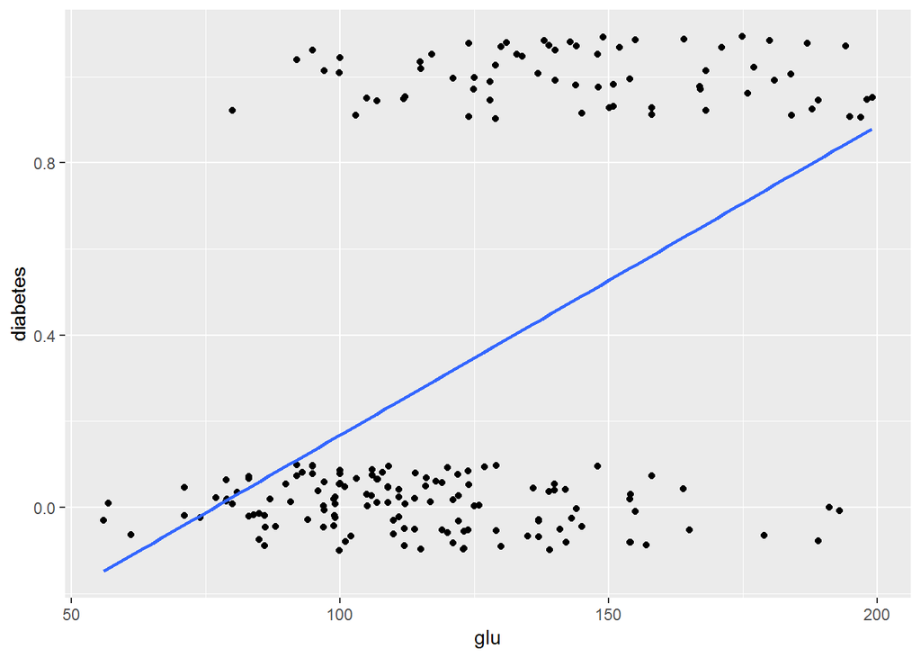

```r
ggplot(datos_ent, aes(x = glu, y = diabetes)) +
    geom_jitter(width=0.1, height=0.1) + geom_smooth(se = FALSE, method = "lm")
```

**¿Qué defecto ves en este modelo? ¿Es posible calcular la devianza de este modelo? ¿Por qué sí o no?

1. Hasta los valores muy altos de glucosa nos dara alta probabilidad alta de diabetes.
2. No, porque al hacer la operación matemática pueden salirnos valores negativos para evaluar en la función log, lo cual no esta definido.

Demuestra que este modelo simple no nos da probabilidades de clase evaluando la predicción en algún valor**:

```r
# escoge un valor problemático para este modelo problemático
valor_malo <- 60
#
mod_lineal <- lm(diabetes ~ glu, data = datos_ent)
predict(mod_lineal, data_frame(glu = valor_malo))
```

```
##          1
## -0.1196894
```

6. Consideremos una mejora usando k-vecinos más cercanos:

```r
library(kknn)
```

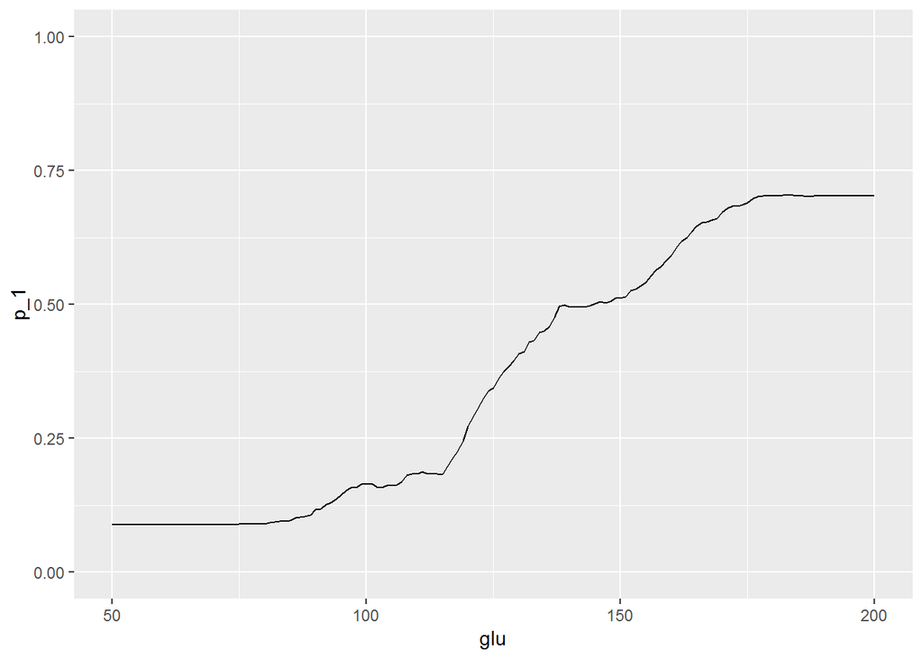

```r
# escoge entre 50 o 60 k-vecinos más cercanos
k <- 55
#
graf_datos <- data_frame(glu = seq(50, 200))
mod_vmc <- kknn(diabetes ~ glu, k = k, train = datos_ent,
              test = graf_datos)
graf_datos$p_1 <- mod_vmc$fitted.values
ggplot(graf_datos, aes(x = glu, y = p_1)) + geom_line() + ylim(c(0,1))
```

**Explica por qué este modelo es más apropiado para este problema de clasificación** ¿Nos da probabilidades?

1. genera probabilidades, lo cual nos ayuda a saber que tan lejanos o cercanos estan nuestros pronosticos.
2. el crecimiento ya no es lineal.
3. ya no tenemos el problema de los negativos.

Si ya que inicia por encima o igial al 0.

7. Agregar la probabilidad estimada según el modelo del inciso anterior a la misma tabla de datos de prueba. Examina la tabla:

```r
preds_vmc <- kknn(diabetes ~ glu, k = k, train = datos_ent, test = datos_pr)
datos_pr$p_1_vmc <- predict(preds_vmc)
datos_pr[,c(1,2,7)]
```

```
## # A tibble: 10 x 3
##    diabetes   glu p_1_vmc
##       <dbl> <int>   <dbl>
##  1        0    99   0.165
##  2        0   100   0.164
##  3        0   112   0.184
##  4        0   123   0.323
##  5        0   129   0.395
##  6        0   142   0.495
##  7        1   171   0.680
##  8        1   186   0.702
##  9        1   189   0.703
## 10        1   193   0.702
```

Examinando la tabla, ¿por qué piensas que este nuevo modelo que usa una covariable puede tener menor devianza? (examina la varaible diabetes y la probabilidad p_1_vmc)

8. Calcula la devianza para cada caso de prueba según el modelo de vecinos más cercanos, y agrega a la tabla. ¿Cúales son los errores más grandes y más chicos con este nuevo modelo? Explica los casos de devianza grande.

Son los valores con glucosa media, lo cual tiene sentido, ya que la probabilidad debe ser cercana 1/2

```r
# termina la siguiente línea
datos_pr$devianza_vmc <- devianza(datos_pr$diabetes,datos_pr$p_1_vmc)
datos_pr[,c(1,2,7,8)]
```

```
## # A tibble: 10 x 4
##    diabetes   glu p_1_vmc devianza_vmc
##       <dbl> <int>   <dbl>        <dbl>
##  1        0    99   0.165        0.361
##  2        0   100   0.164        0.359
##  3        0   112   0.184        0.406
##  4        0   123   0.323        0.780
##  5        0   129   0.395        1.01
##  6        0   142   0.495        1.37
##  7        1   171   0.680        0.771
##  8        1   186   0.702        0.706
##  9        1   189   0.703        0.706
## 10        1   193   0.702        0.706
```

9. Calcula la devianza promedio de prueba para el modelo de vecinos más cercanos

```r
# escribe aquí la línea de código que calcula la devianza promedio
mean(datos_pr$devianza_simple)
```

```
## [1] 1.361666
```

```r
mean(datos_pr$devianza_simple_0.75)
```

```
## [1] 1.893699
```

```r
mean(datos_pr$devianza_vmc)
```

```
## [1] 0.7167868
```

10. Aunque la muestra de prueba es chica, ¿cuál es el mejor modelo según la devianza de prueba, el simple o el de vecinos más cercanos?

Comparando vs el modelo simple, vemos una gran mejora en el cálculo de la devianza para vecinos más cercanos.